# Final Project

George Butvilas

22 May, 2020

# Packages and Data

```r
library(tidyverse)
library(Hmisc)
```

```r
bulls <- read.csv("BullsSeasons.csv")
str(bulls)
TW <- read.csv("TWMasters19.csv") %>%
  mutate(Player=factor(Player,levels=c("Tiger Woods","Brooks Koepka","Dustin Johnson","Xander Schauffele")))
str(TW)
```

# The Chicago Bulls Under Phil Jackson

The Chicago Bulls are considered as one of the best franchises ever in NBA history. Up until the 1990s, the Bulls had not yet won an NBA championship. That all changed when Phil Jackson was hired in 1990 and the Bulls went on to win six NBA championships in Jackson’s nine year tenure as head coach. After winning their sixth NBA championship in nine years, Bulls GM Jerry Krause fired Phil Jackson due to Krause wanting to “rebuild” the franchise. My question is, how did the Bulls fair without Phil Jackson? As you can see in the graph, not very well. From 1999 to 2010, the Bulls did not win over 50 regular season games, which Jackson did eight out of the nine seasons when he was head coach, and went through five coaching changes. Jackson went on to coach the Los Angeles Lakers to three championships from 2000 to 2002. You tell me, should Krause have fired Phil Jackson? Probably not. I used a line graph with points to show the difference between higher and lower regular season wins. The red line is used to show Jackson’s tenure with the Bulls and the blue points are used to show the championships the Bulls have won. The background is white because it looked simple and clean as it best suited the data. The labels are used to show different significant points in the plot. The goal of the plot was to highlight that the Chicago Bulls were atrocious without Phil Jackson as head coach.

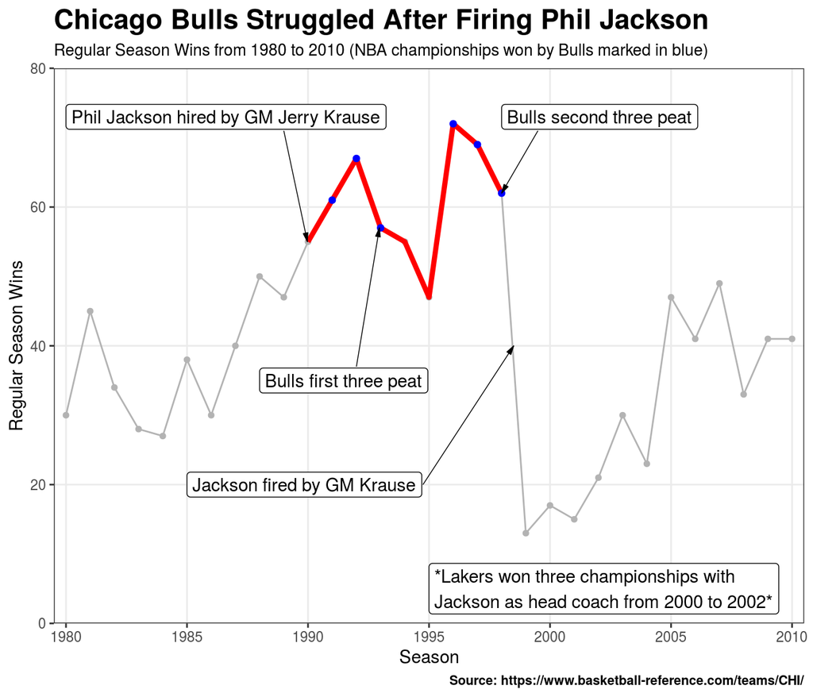

```r
b25 <- ggplot(data=bulls,mapping=aes(x=Season,y=Wins)) +
  geom_point(size=1.25,color="gray70") +
  geom_line(color="gray70") +
  geom_line(data=filter(bulls,Season>=1990,Season<=1998),mapping=aes(x=Season,y=Wins),color="red",size=1.5) +
  geom_point(data=filter(bulls,Season>=1991,Season<=1993),mapping=aes(x=Season,y=Wins),color="blue",size=1.5) +
  geom_point(data=filter(bulls,Season>=1996,Season<=1998),mapping=aes(x=Season,y=Wins),color="blue",size=1.5) +
  scale_x_continuous(name="Season",limits=c(1980,2010),breaks=seq(1980,2010,5),expand=expansion(0,0.5)) +
  labs(title="Chicago Bulls Struggled After Firing Phil Jackson",
       subtitle="Regular Season Wins from 1980 to 2010 (NBA championships won by Bulls marked in blue)",
       caption="Source: https://www.basketball-reference.com/teams/CHI/",
       x=element_blank(),y=element_blank()) +
  scale_y_continuous(name="Regular Season Wins",expand=expansion(0,0),limits=c(0,80)) +
  theme_bw() +
  theme(panel.grid.minor.x=element_blank(),
        panel.grid.minor.y=element_blank(),
        plot.title=element_text(color="black",face="bold",size=17),
        plot.subtitle=element_text(color="black",size=10),
        plot.caption=element_text(color="black",face="bold",size=8))
b25 + annotate(geom="label",x=1980,y=73,hjust="left",
           label="Phil Jackson hired by GM Jerry Krause",color="black") +
  annotate(geom="segment",x=1989,y=71,xend=1989.975,yend=55,size=0.25,
    arrow=arrow(length=unit(2,"mm"),angle=15,type="closed"),color="black") +
  annotate(geom="label",x=1988,y=35,hjust="left",
           label="Bulls first three peat",color="black") +
  annotate(geom="segment",x=1992,y=37,xend=1992.95,yend=57,size=0.25,
    arrow=arrow(length=unit(2,"mm"),angle=15,type="closed"),color="black") +
  annotate(geom="label",x=1998,y=73,hjust="left",
           label="Bulls second three peat",color="black") +
  annotate(geom="segment",x=1999.5,y=71,xend=1998,yend=62,size=0.25,
    arrow=arrow(length=unit(2,"mm"),angle=15,type="closed"),color="black") +
  annotate(geom="label",x=1985,y=20,hjust="left",
           label="Jackson fired by GM Krause",color="black") +
  annotate(geom="segment",x=1994.75,y=20,xend=1998.5,yend=40,size=0.25,
    arrow=arrow(length=unit(2,"mm"),angle=15,type="closed"),color="black") +
  annotate(geom="label",x=1995,y=5,hjust="left",
           label="*Lakers won three championships with
Jackson as head coach from 2000 to 2002*",color="black")
```

# Against All Odds: Tiger Woods 2019 Masters

Tiger Woods is arguably the best golfer to ever play on the PGA Tour. He has won 15 major tournaments, which is second all time, and 82 PGA Tour events, which is tied for first all time. From 1999 to 2010, he was ranked the top golfer for 545 weeks and won 13 majors in that time. After 2010, it was a different story. Plagued by out of sport issues, injuries and setbacks, Tiger fell off. He would golf in only one tournament between August of 2015 and January of 2018. All of this changed in April of 2019 at Augusta National Golf Club at the 2019 Masters Golf tournament. The Masters is considered one of the biggest golf tournaments on the PGA Tour and is known for the winners getting the famous “green jacket”. Coming into the 2019 Masters, Tiger Woods knew the golf course well and knew what he had to do to win. And he did. Tiger Woods won his first major in 11 years and his fourth green jacket at Augusta at the age of 43. My question was, did he win handsomely or was it close? At the start of the final round, Tiger was in first winning by one stroke. Three young promising players, Brooks Koepka, Dustin Johnson, and Xander Schauffele were coming into the final round with something to prove. While trying to catch Tiger, they all came up short. One stroke short. So yes, it was very close. I used a line plot to show how the different golfers scores led up to their ultimate score. I did not facet these lines because it would be hard to see the comparison of scores between each player. I used a black theme and lighter colors to make the lines pop out at the reader more. The goal of the plot was to illustrate how Tiger narrowly won the 2019 Masters golf tournament.

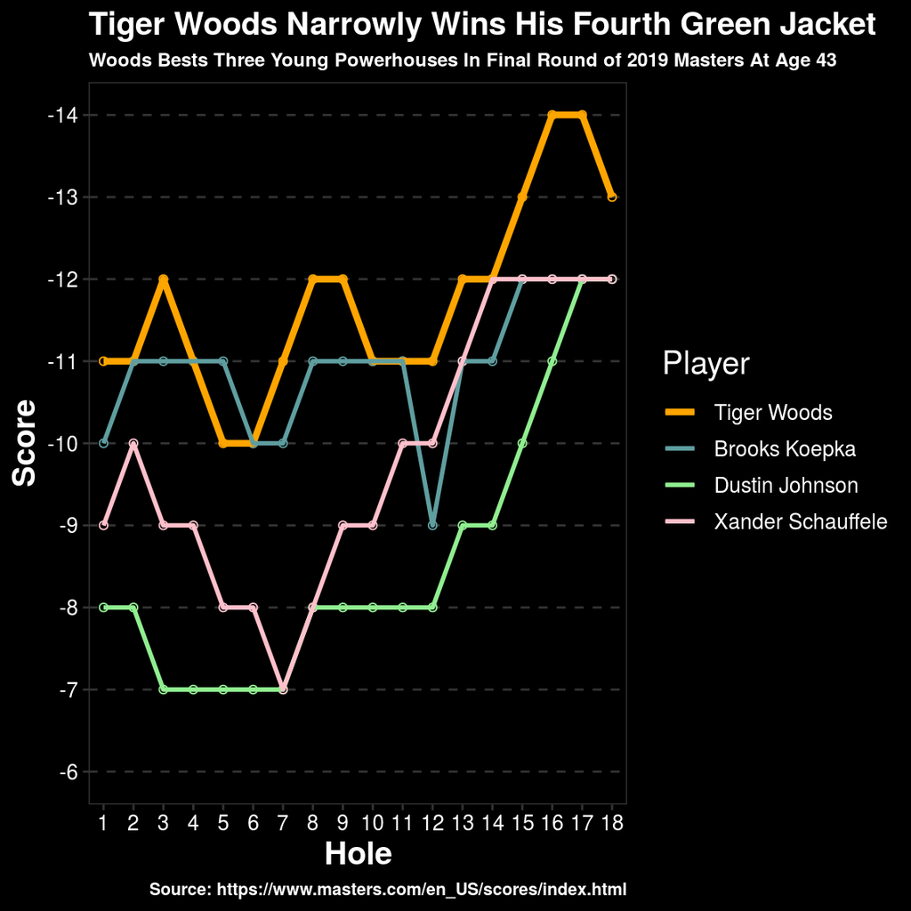

```r
b65 <- ggplot(data=TW,mapping=aes(x=Hole,y=Score,color=Player)) +
  geom_line() +
  geom_point(pch=21,show.legend = FALSE) +
  geom_line(mapping=aes(x=Hole,y=Score,color=Player,size=Player)) +
  scale_size_manual(values=c(1.5,1,1,1)) +
  scale_fill_manual(values=c("black","yellow","blue","green")) +
  scale_y_reverse(name="Score",breaks=seq(-14,-6,1),limits=c(-6,-14)) +
  scale_x_continuous(expand=expansion(0,0.5),limits=c(1,18),breaks=seq(1,18,1)) +
  scale_color_manual(values=c("orange","cadetblue","lightgreen","pink")) +
  theme_bw() +
  labs(title="Tiger Woods Narrowly Wins His Fourth Green Jacket",
       subtitle="Woods Bests Three Young Powerhouses In Final Round of 2019 Masters At Age 43",
       caption="Source: https://www.masters.com/en_US/scores/index.html") +
  theme(panel.grid.major.x=element_blank(),
        panel.grid.minor=element_blank(),
        panel.background=element_rect(fill="black"),
        plot.background=element_rect(fill="black",color="black"),
        axis.title.y=element_text(color="white",face="bold",size=15),
        axis.title.x=element_text(color="white",face="bold",size=15),
        axis.text=element_text(color="white",size=10),
        panel.grid.major=element_line(color="gray20",linetype="dashed"),
        legend.background=element_rect(fill="black"),
        legend.text=element_text(color="white",size=10),
        legend.title=element_text(color="white",size=15),
        legend.key=element_rect(fill="black",color="black"),
        plot.title=element_text(color="White",face="bold",size=15),
        plot.subtitle=element_text(color="White",face="bold",size=9),
        plot.caption=element_text(color="White",face="bold",size=8))
b65
```